# Anticipatory Action Trigger Mechanism Report

Typhoons in The Philippines

Last updated: 2023-01-27

## Key Messages

- RAPID INTENSIFICATION

  The main challenge for this trigger model is due to rapid intensification (RI). While the impact estimation is also a source of uncertainty, all missed activations can be attributed to underestimates in the climate forecast due to RI.
- ACTIVATION

  There is a 3 - 17% chance that a full activation (both readiness and activation trigger) will occur in a given year.
- MISSED ACTIVATIONS

  The risk of not activating in the presence of a severe shock stands at 75 - 94% of shocks. Note that in every case of a missed activation, the typhoon experienced RI or the forecast was still underestimating the severity at the leadtime used.
- FALSE ALARMS

  The risk of activating in the absence of a severe shock stands at 0 - 67% of activations.
- NO REGRETS BIAS

  The mechanism is optimised to reduce the risk of failing to activate when there is a shock, at the cost of having false alarms.

## About Metric Estimates

The estimates in this report are shown as ranges called confidence intervals. The confidence intervals reflect the probabilistic nature of the estimates as well as the impact of data limitations (small or incomplete datasets, errors or imprecision in measurements, divergences between data sources, etc.) on the accuracy of estimates. They can inform decision-making by illustrating the most likely performance levels and by providing bounds for the possible albeit unlikely extremes.

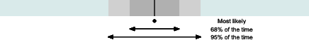

- The central value is the most likely performance;
- Most often the trigger will perform within the darker inner range (68% of the time);
- There is high confidence that the trigger will perform within the full coloured (grey or blue) range (95% of the time).

## Colour Coding

In the visualizations blue represents activation likelihood, green represents desired outcomes (valid non-activations/activations) and red represents undesired outcomes or errors.

## Trigger Mechanism Snapshot

This table summarises the trigger mechanism and its performance in signaling severe shocks. It presents estimates of the likelihood that the threshold would be met in a given year as well as how often the trigger is expected to correctly recommend an activation or non-activation.

Readiness Trigger

Activation Trigger

Full Framework

**Description**

Lead Time

4-7 days before landfall

72 hours before landfall

N/A

Data Source

PAGASA, ECMWF, GEFS, Weather Nerds

ECMWF, NLRC 510 Global damage impact model

N/A

Historical Data Coverage

2006 - 2021

2006 - 2021

N/A

Monitored by

OCHA Philippines

OCHA Philippines

N/A

**Programming and Funding**

Probability of being met in a given year

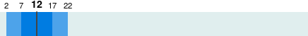

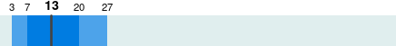

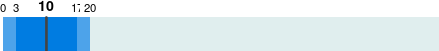

**Performance**

All Activations (%)

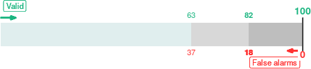

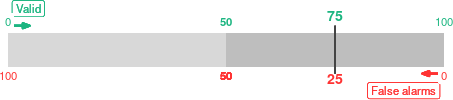

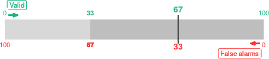

All Shocks (%)

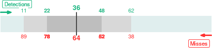

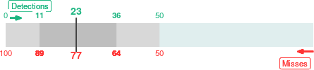

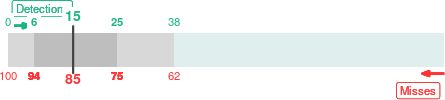

Notes

The readiness and activation trigger can reach their threshold and activate independently from one another. The full framework activation is met only if both the readiness and activation triggers are reached. (Unlike in other rapid-onset pilots, the readiness trigger MUST be met in order for the activation trigger to go forward. If only one of the two triggers is reached, no interventions will take place). The readiness trigger performance was assessed by comparing recommended activations with historical typhoon forecasts, and the activation trigger by running the 510 model on ECMWF hindcasts. Recommended activations were defined as historical typhoons that caused more than 5,000 buildings to be severely damaged in regions 5, 8, and 13.

## Technical Team

OCHA Philippines, 510 Global have provided data and/or analytical support.

## Monitoring Process

Between September and January, OCHA Philippines monitors typhoon forecasts from the Philippine Atmospheric, Geophysical and Astronomical Services Administration (PAGASA), the European Centre for Medium-Range Weather Forecasts (ECMWF), the Global Ensemble Forecast System (GEFS), and Weather Nerds (Private Initiative). If the typhoon is projected to impact areas in regions 5, 8 and 13 within 4-7 days, and exceed 178 km/h 1-minute sustained wind speed, then the readiness trigger is reached, with either scenario 1 (Regions 5 and 8) or 2 (Regions 8 and 13) specified. For more information on the scenario definition, please refer to the trigger framework. 72 hours before landfall, the 510 damage assessment model is run. If any of the damage numbers exceed the thresholds specified in the framework impact matrix by the target probability (ranging from 50% probability that 80,000 houses or more will be totally damaged, to 95% probability that 5,000 will be totally damaged), then the activation trigger is reached. Note that for a successful activation, both the readiness and activation trigger need to be reached.

## Learning Opportunities

This table summarises the decisions, assumptions, and open questions that arose during trigger development. They are documented for transparency and to inform the learning agenda.

| Decision | Rationale | Assumption | Open Question |
| --- | --- | --- | --- |
| Readiness trigger must be reached for framework to activate | Short activation time window requires that readiness activities have already been implemented | Forecast performance is sufficient at 4-7 days leadtime | How does this requirement impact the framework performance |
| Readiness trigger split into two scenarios | Different activities and implementing partners in the two regions | Typhoon forecast will have a clear scenario and track will not deviate | How often do we expect an amgiguous forecast or scenario change |
| Action trigger set to have 3 days lead time | Interventions need to begin at least 3 days prior to landfall | Forecast performance is suficient at 3 days lead time | Could shorter lead-time interventions be considered to mitigate the challenge of RI |